# Analysis of compartment-specific gene expression in breast cancer tumors

## Introdução

O cancro leva a um crescimento anormal das células devido a mutações em genes, este crescimento pode ser visto como a transcrição do gene ou seja, irá haver mais produção de mRNA, quantificado como o nível de expressão genética. Os nossos dados correspondem a 3 amostras dos 3 compartimentos, somando 9 amostras para cada gene. Os tumores de mama que são considerados como “triplo negativo” correspondem a 20% dos cancros mamários, sendo que estes não contêm recetores de estrogénio (núcleo), progesterona (núcleo) ou HER2 (membrana/citoplasma).

## Carregar Dados

A libraria usada para os nossos dados foi a “pd.hugene.1.0.st.v1”. De modo a carregar os dados que se encontravam em formato .CEL foi necessário recorrer à livraria “oligo” que seguidamente procedemos à sua normalização via Robust Multichip Average (RMA) que nos irá dar os nossos dados de expressão genética. Estes dados já foram transformados usando log2 e normalizados.

```r
library(pd.hugene.1.0.st.v1)
library(oligo)
setwd("~/GitHub/Data_Analysis/dataset")
celFiles <- list.celfiles()
affyRaw <- read.celfiles(celFiles)
```

```
## Reading in : GSM1446286_Can1.CEL
## Reading in : GSM1446287_Str1.CEL
## Reading in : GSM1446288_Tot1.CEL
## Reading in : GSM1446289_Can2.CEL
## Reading in : GSM1446290_Str2.CEL
## Reading in : GSM1446291_Tot2.CEL
## Reading in : GSM1446292_Can3.CEL
## Reading in : GSM1446293_Str3.CEL
## Reading in : GSM1446294_Tot3.CEL
```

```r
eset <- rma(affyRaw)#normalização dos dados
```

```
## Background correcting
## Normalizing
## Calculating Expression
```

Para um melhor tratamento dos dados foi retirado a informação destes dados de expressão e colocados num data frame com 33297 linhas (genes) por 9 colunas que correspondem a 3 amostras para 3 localizações por cada amostra, nomeadamente o estroma, a célula cancerígena e o tecido tumoral.

```r
# Guarda os dados em txt,os dados são transformados em log2 e normalizados
write.exprs(eset,file="data.txt")
my_frame <- data.frame(exprs(eset))
#ver data framme
View(my_frame)
dim(my_frame)
```

```
## [1] 33297     9
```

```r
class(my_frame)
```

```
## [1] "data.frame"
```

```r
featureNames(eset)[1:5]
```

```
## [1] "7892501" "7892502" "7892503" "7892504" "7892505"
```

```r
sampleNames(eset)[1:5]
```

```
## [1] "GSM1446286_Can1.CEL" "GSM1446287_Str1.CEL" "GSM1446288_Tot1.CEL"
## [4] "GSM1446289_Can2.CEL" "GSM1446290_Str2.CEL"
```

```r
annotation(eset)
```

```
## [1] "pd.hugene.1.0.st.v1"
```

O nosso data set de expressão genética não apresenta informações sobre atributos das amostras ou mesmo sobre a experiência realizada.

```
varMetadata(eset) # nao tem descrição das amostras
phenoData(eset) #nao tem informação
experimentData(eset) #nao tem informação
abstract(eset) #nao tem informação
```

Procedemos à verificação dos dados para verificar se existiam valores omissos ou elementos que não fossem números. Portanto a soma deste tipo de valores foi nulo em todas as colunas, isto é não existem valores omissos ou não números no nosso dataset.

```
sum(is.na(my_frame$GSM1446286_Can1.CEL))
sum(is.nan(my_frame$GSM1446286_Can1.CEL))
sum(is.na(my_frame$GSM1446287_Str1.CEL))
sum(is.nan(my_frame$GSM1446287_Str1.CEL))
sum(is.na(my_frame$GSM1446288_Tot1.CEL))
sum(is.nan(my_frame$GSM1446288_Tot1.CEL))
sum(is.na(my_frame$GSM1446289_Can2.CEL))
sum(is.nan(my_frame$GSM1446289_Can2.CEL))
sum(is.na(my_frame$GSM1446290_Str2.CEL))
sum(is.nan(my_frame$GSM1446290_Str2.CEL))
sum(is.na(my_frame$GSM1446291_Tot2.CEL))
sum(is.nan(my_frame$GSM1446291_Tot2.CEL))
sum(is.na(my_frame$GSM1446292_Can3.CEL))
sum(is.nan(my_frame$GSM1446292_Can3.CEL))
sum(is.na(my_frame$GSM1446293_Str3.CEL))
sum(is.nan(my_frame$GSM1446293_Str3.CEL))
sum(is.na(my_frame$GSM1446294_Tot3.CEL))
sum(is.nan(my_frame$GSM1446294_Tot3.CEL))
```

## Filtros

A livraria “genefilter” irá ser usada para selecionar apenas os genes que mais interessam para o nosso caso. Decidimos filtrar as amostras pelo valor do desvio padrão em que os valores do data frame cujo desvio padrão for superior ou igual a 2 vezes a mediana. O que significa que os valores têm maior variabilidade isto é, há uma maior diferença entre eles o que causa um certo interesse nestes genes, pois os genes normais produzem praticamente a mesma quantidade de mRNA ao longo do tempo, mantendo a sua actividade normal.

```r
library(genefilter)
sds=rowSds(my_frame)#calcula o desvio padrao por linha
sds[1:15] #Ver os primeiros 15 desvios padroes
```

```
##   7892501   7892502   7892503   7892504   7892505   7892506   7892507
## 0.2509900 0.4123594 0.4497060 0.3123580 0.4136020 0.2096954 0.4402805
##   7892508   7892509   7892510   7892511   7892512   7892513   7892514
## 0.6388931 0.7788207 0.8948506 0.3192589 0.3459729 0.1925958 0.6673569
##   7892515
## 0.2121785
```

```r
m=median(sds)#mediana de desvios de padroes
m
```

```
## [1] 0.2639786
```

```r
mean(sds)
```

```
## [1] 0.326549
```

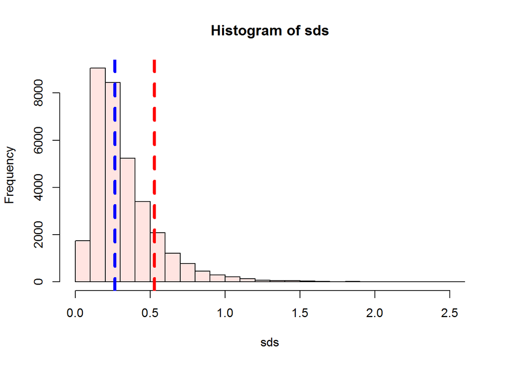

```r
hist(sds, breaks=20, col="mistyrose")
abline(v=m, col="blue", lwd=4, lty=2)
abline(v=m*2, col="red", lwd=4, lty=2)
```

```r
new_frame=my_frame[sds >= 2*m, ]
```

Os genes com pouca variação nas diversas amostras não são biologicamente relevantes. Realizamos outro tipo de filtragem em que só seriam considerados os genes em que o valor dado pela divisão entre o valor máximo e mínimo fosse superior a 2 isto é, a diferença entre o máximo e o mínimo irá ser elevado.

```r
maximos=apply(my_frame,1,max)# maximos do valor de expressao dos genes
minimos=apply(my_frame,1,min)# minimo do valor de expressao dos genes
#maximo valor de gene expression
max(maximos)
```

```
## [1] 14.2328
```

```r
#minimo valor de gene expression
min(minimos)
```

```
## [1] 1.951902
```

```r
vl=maximos/minimos>2
new_frame2=my_frame[vl,]#Data frame filtrado com  genes cujo rácio do máximo valor sobre o mínimo valor de expressão seja superior a 2
```

Uma filtragem diferente seria através do quantis, mas não iremos utilizar este dataframe, apenas será utilizado o **new_frame2** para os processos seguintes.

```
## keep top 50 percent
filter=varFilter(eset, var.func=IQR, var.cutoff=0.5, filterByQuantile=TRUE)
frame_var_filter <- data.frame(exprs(filter))
```

## Expressão Diferencial

```r
require(Biobase)
object<-new("ExpressionSet", exprs=as.matrix(new_frame2))# transformar o newframe2 em  expression set
object
```

```
## ExpressionSet (storageMode: lockedEnvironment)
## assayData: 97 features, 9 samples
##   element names: exprs
## protocolData: none
## phenoData: none
## featureData: none
## experimentData: use 'experimentData(object)'
## Annotation:
```

```r
tt = rowttests(object)#Realiza os t-tests e verificar os p-values
#Novo dataframe ordenado pela coluna de p value
pvalueorder= tt[order(tt$p.value),]
pvalueorder$p.value[1:20]# primeiros 20 resultados com menor p value
```

```
##  [1] 1.325583e-07 1.573143e-07 1.833574e-07 1.959976e-07 2.582384e-07
##  [6] 2.730650e-07 3.002367e-07 3.870482e-07 4.274203e-07 4.464951e-07
## [11] 4.545754e-07 5.610038e-07 5.643108e-07 5.855470e-07 6.030047e-07
## [16] 6.243037e-07 6.552610e-07 7.057502e-07 7.069462e-07 7.935695e-07
```

```r
library(hugene10sttranscriptcluster.db)
rr=rownames(pvalueorder)[1:20]
unlist(mget(rr, hugene10sttranscriptclusterENTREZID))
```

```
## 7894783 7894409 7896406 7896000 7895005 7895287 7954196 7981992 7894287
##      NA      NA      NA      NA      NA      NA  "4257"      NA      NA
## 7892610 7981724 7981728 7895618 7893104 8115366 7893942 7896708 8111915
##      NA      NA      NA      NA      NA      NA      NA      NA  "6414"
## 7895567 7894958
##      NA      NA
```

## Informação dos genes

De modo a obter informação sobre os genes, tivemos que proceder a uma pesquisa extensa, pois o annotation “pd.hugene.1.0.st.v1” não correspondia à base de dados, de modo a encontrar o nome da livraria correspondente (a base de dados).

```r
ob=featureNames(object)
unlist(mget(ob, hugene10sttranscriptclusterSYMBOL))
```

```
##       7892590       7892609       7892610       7892630       7892732
##            NA            NA            NA            NA            NA
##       7892744       7892819       7892982       7893104       7893108
##            NA            NA            NA            NA            NA
##       7893193       7893253       7893484       7893532       7893620
##            NA            NA            NA            NA            NA
##       7893622       7893942       7894238       7894287       7894310
##            NA            NA            NA            NA            NA
##       7894409       7894528       7894783       7894792       7894852
##            NA            NA            NA            NA            NA
##       7894869       7894895       7894958       7895005       7895029
##            NA            NA            NA            NA            NA
##       7895103       7895151       7895287       7895294       7895352
##            NA            NA            NA            NA            NA
##       7895413       7895524       7895567       7895618       7895655
##            NA            NA            NA            NA            NA
##       7896000       7896001       7896129       7896233       7896283
##            NA            NA            NA            NA            NA
##       7896406       7896431       7896460       7896530       7896584
##            NA            NA            NA            NA            NA
##       7896703       7896708       7896712       7896724       7896728
##            NA            NA            NA            NA            NA
##       7896729       7897522       7917182       7921434       7922412
##            NA        "RBP7"       "ELTD1"        "AIM2"            NA
##       7931832       7937772       7940987       7947156       7954196
##      "AKR1C2"            NA            NA       "MUC15"       "MGST1"
##       7961151       7965403       7965410       7965767       7976812
##            NA         "LUM"         "DCN"            NA  "SNORD113-4"
##       7976816       7981724       7981728       7981732       7981980
##  "SNORD114-3"            NA            NA            NA "SNORD116-16"
##       7981992       8022279       8043436       8043441       8043468
##            NA            NA            NA            NA            NA
##       8053718       8077366       8088844       8089544       8095435
##            NA       "LRRN1"            NA      "CCDC80"        "HTN1"
##       8095456       8095477       8100827       8102948       8105331
##        "ODAM"        "CSN3"         "IGJ"            NA        "GZMK"
##       8111915       8115366       8133876       8135774       8141094
##       "SEPP1"            NA        "CD36"      "PTPRZ1"        "PDK4"
##       8144719       8151532
##            NA       "FABP4"
```

```r
#unlist(mget(ob, hugene10sttranscriptclusterGENENAME))
unlist(mget(ob, hugene10sttranscriptclusterENTREZID))
```

```
##     7892590     7892609     7892610     7892630     7892732     7892744
##          NA          NA          NA          NA          NA          NA
##     7892819     7892982     7893104     7893108     7893193     7893253
##          NA          NA          NA          NA          NA          NA
##     7893484     7893532     7893620     7893622     7893942     7894238
##          NA          NA          NA          NA          NA          NA
##     7894287     7894310     7894409     7894528     7894783     7894792
##          NA          NA          NA          NA          NA          NA
##     7894852     7894869     7894895     7894958     7895005     7895029
##          NA          NA          NA          NA          NA          NA
##     7895103     7895151     7895287     7895294     7895352     7895413
##          NA          NA          NA          NA          NA          NA
##     7895524     7895567     7895618     7895655     7896000     7896001
##          NA          NA          NA          NA          NA          NA
##     7896129     7896233     7896283     7896406     7896431     7896460
##          NA          NA          NA          NA          NA          NA
##     7896530     7896584     7896703     7896708     7896712     7896724
##          NA          NA          NA          NA          NA          NA
##     7896728     7896729     7897522     7917182     7921434     7922412
##          NA          NA    "116362"     "64123"      "9447"          NA
##     7931832     7937772     7940987     7947156     7954196     7961151
##      "1646"          NA          NA    "143662"      "4257"          NA
##     7965403     7965410     7965767     7976812     7976816     7981724
##      "4060"      "1634"          NA    "767564"    "767579"          NA
##     7981728     7981732     7981980     7981992     8022279     8043436
##          NA          NA "100033428"          NA          NA          NA
##     8043441     8043468     8053718     8077366     8088844     8089544
##          NA          NA          NA     "57633"          NA    "151887"
##     8095435     8095456     8095477     8100827     8102948     8105331
##      "3346"     "54959"      "1448"      "3512"          NA      "3003"
##     8111915     8115366     8133876     8135774     8141094     8144719
##      "6414"          NA       "948"      "5803"      "5166"          NA
##     8151532
##      "2167"
```

Nota: Uma grande parte dos genes não estão mapeados.

## Clustering

Para visualizar genes que são próximos em termos de nível de expressão, iremos realizar um clustering (agrupamento) dos dados, caso os genes estejam próximos podem estar relacionados funcionalmente podendo, também, ter a mesma via metabólica. No primeiro cluster hierarquico temos 3 conjuntos de genes que são mais próximos, que neste caso se traduz numa proximidade relativa ao nível de expressão.

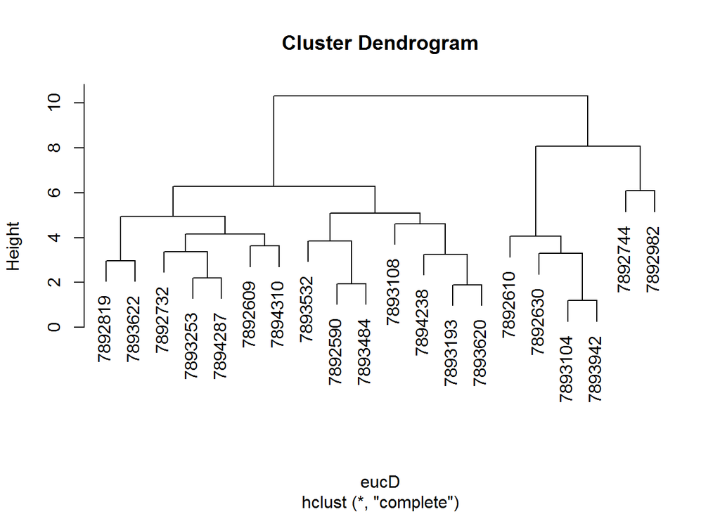

```r
eucD = dist(exprs(object[1:20]))
cl.hier <- hclust(eucD)
plot(cl.hier)
```

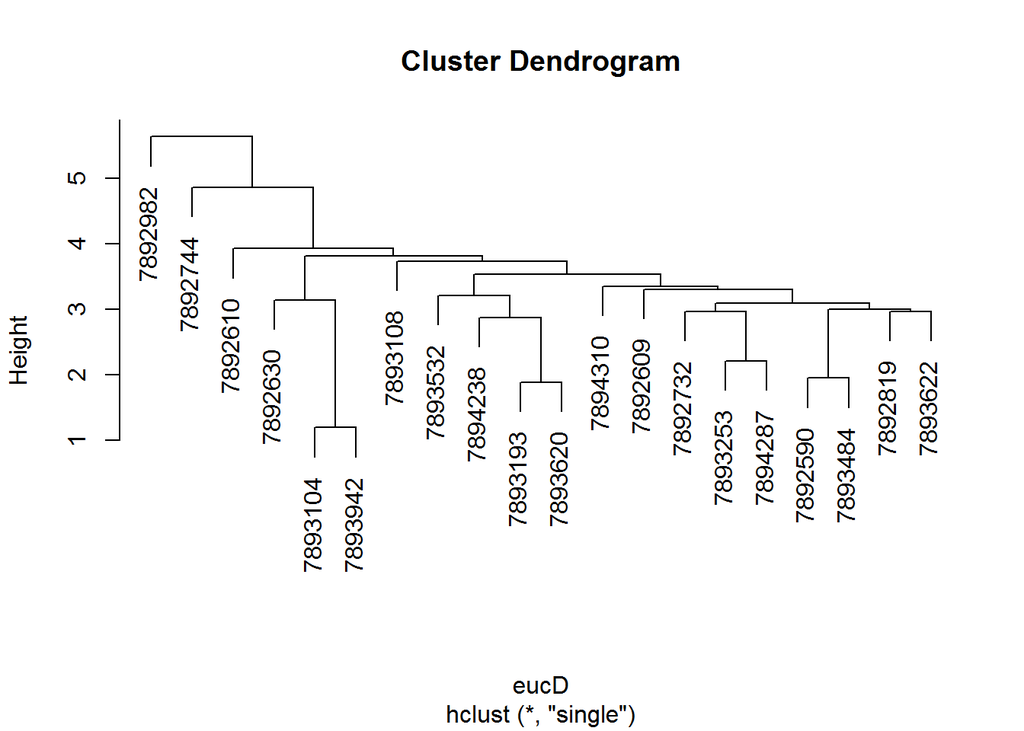

```r
cl.hier <- hclust(eucD, method="single")
plot(cl.hier)
```

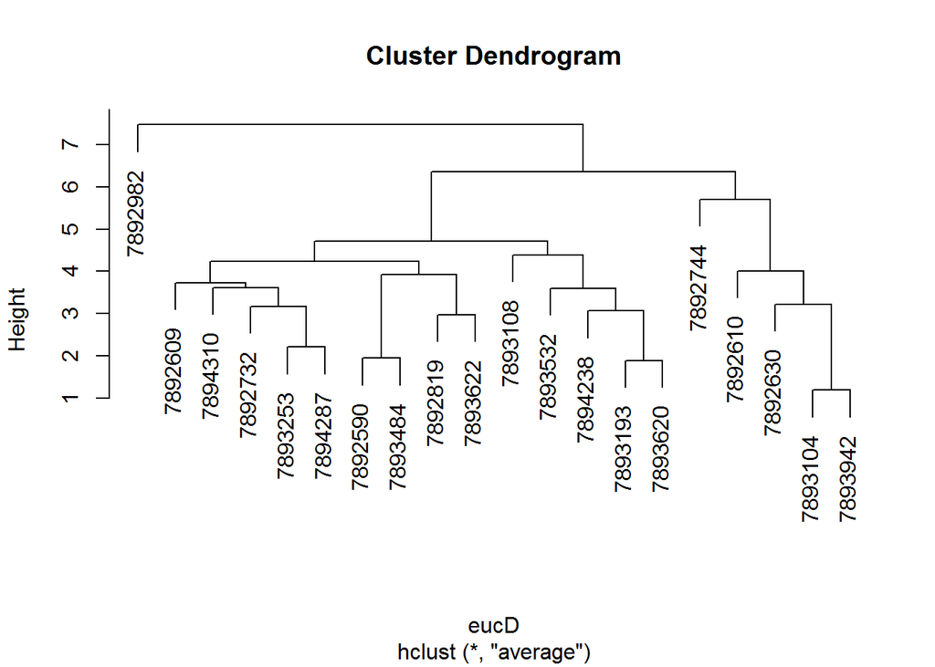

```r
cl.hier <- hclust(eucD, method="average")
plot(cl.hier)
```

## Heatmap

É uma forma de representar dados matriciais onde cores de cada délula representam uma escala de valores. O heatmap criado em R inclui o clustering hierarquico realizado quer ao nível das linhas quer ao nível das colunas.

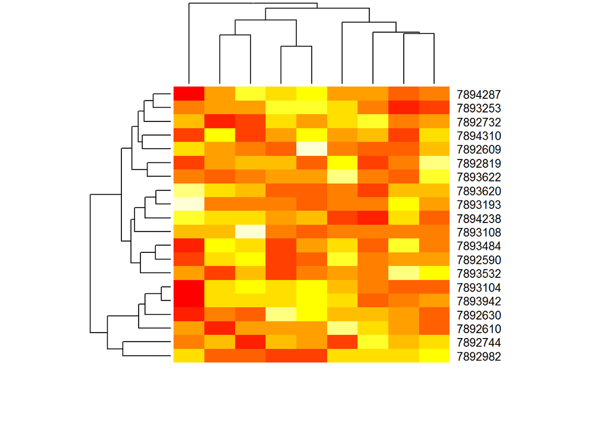

```r
heatmap(exprs(object[1:20]), labCol = F)
```

O clustering k-means indica-nos o cluster onde cada gene está alojado. É vantajoso caso quisermos encontrar grupos com vários elementos, mas também pode levar a um mau agrupamento, pois os outros elementos podem ser piores.

```r
#kmeans
km = kmeans(exprs(object[1:20]), 3)
names(km)
```

```
## [1] "cluster"      "centers"      "totss"        "withinss"
## [5] "tot.withinss" "betweenss"    "size"         "iter"
## [9] "ifault"
```

```r
km$cluster
```

```
## 7892590 7892609 7892610 7892630 7892732 7892744 7892819 7892982 7893104
##       2       1       3       3       2       3       2       3       3
## 7893108 7893193 7893253 7893484 7893532 7893620 7893622 7893942 7894238
##       1       1       2       2       1       1       2       3       1
## 7894287 7894310
##       2       2
```

## Exemplo para genes com identificador

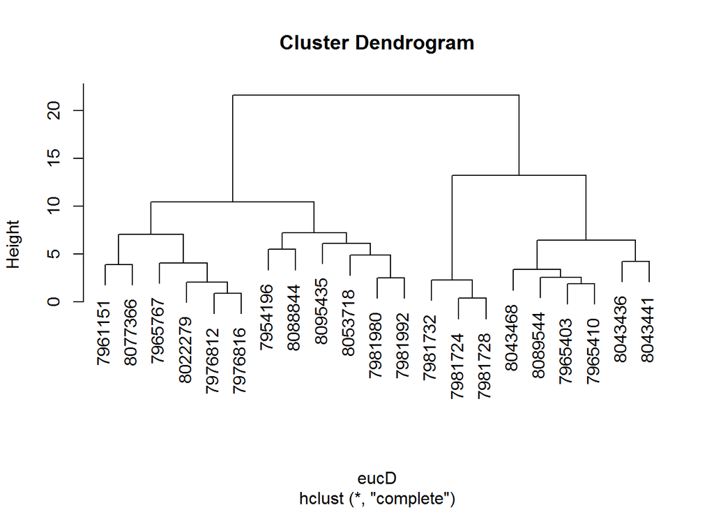

```r
eucD = dist(exprs(object[65:85]))
cl.hier <- hclust(eucD)
plot(cl.hier)
```

```r
bb=rownames(exprs(object[65:85]))
unlist(mget(bb, hugene10sttranscriptclusterENTREZID))
```

```
##     7954196     7961151     7965403     7965410     7965767     7976812
##      "4257"          NA      "4060"      "1634"          NA    "767564"
##     7976816     7981724     7981728     7981732     7981980     7981992
##    "767579"          NA          NA          NA "100033428"          NA
##     8022279     8043436     8043441     8043468     8053718     8077366
##          NA          NA          NA          NA          NA     "57633"
##     8088844     8089544     8095435
##          NA    "151887"      "3346"
```

## Discussão

Como podemos ver através da imagem anterior, temos os genes 7976812 e 7976816 que são próximos e estão no mesmo cluster, com os IDs 767564 e 767579, respectivamente. Após uma pesquisa podemos reparar que ambos estão localizados aproximadamente na mesma região do cromossoma 14 e considerados *small nucleolar RNA*. Além destes dois genes, temos 7965403 e 7965410 com os IDs 4060 e 1634, respectivamente. As proteínas codificadas estão envolvidas em alguns processos biológicos comuns às duas, os genes estão localizados aproximadamente na mesma região do cromossoma 12, devido a isto têm níveis de expressão muito próximos. Estes últimos genes codificam proteínas presentes no tecido conjuntivo, estando expressos maioritariamente no estroma